# World Progress and Development Indicators

# Global CO2 emissions rising rapidly, largely accounted for by upper-middle income countries

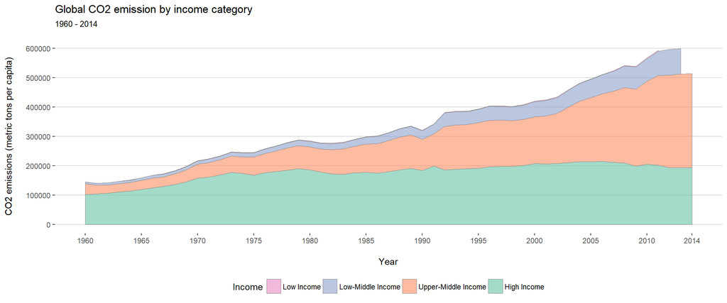

This visualization shows the change over time of CO2 emissions globally, grouped by countries which call into different income categories: low income, low-middle income, upper-middle income, and high-income. The filled-area chart is a standard but effective visualization for showing this type of relationship. I chose to make the colours slightly transparent so that the viewer could see the vertical grid lines through each area. This visualization makes it easy to see that global CO2 emissions have rose greatly between 1960 and 2014 and that this rise has been most dramatic in upper-middle income countries. As expected, low income countries barely produce CO2 emissions because they are not developed enough industrially to produce gas emissions at a large scale. High income countries seem to be emitting CO2 at a consistent rate over the years. Perhaps this has something to do with population sizes.

# Resource depletion greatest in lower income countries, especially African nations

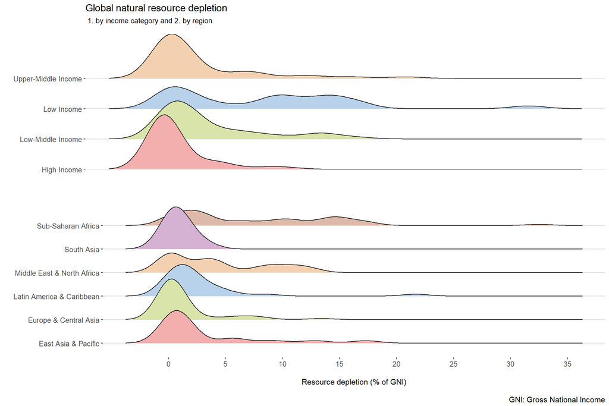

This visualization is actually two ridge plots which I combined together. This was done by stacking them on top of each other and removing x-axis label and values of the top plot and the title of the bottom plot to avoid unnecessary repetition. This also created the illusion of a single plotting window. This type of plot is useful for comparing distributions, specifically multiple density plots. The colour scheme is again based off Few’s recommendations. Each distribution is outlined in black to make the overlapping areas more distinct and the disturbing clearer across the white background.

Resource depletion (as percentage of gross national income) is displayed for both world regions and income categories. Looking at the income grouping of distributions, high and upper-middle income countries have mostly low percentages of resource depletion and are positively skewed. The distributions of low and low-middle income countries contain more countries with higher rates of resource depletion. This makes sense as the two issues are closely connected, with countries with less resources or poor management of resources experiencing economic burden. Looking at the regional grouping of distributions, a similar story can be seen from a distinct perspective. Sub-Saharan Africa explains a lot about the resource depletion distribution of low income countries see in the first grouping. This region has some countries with very high depletion of resources.

# Greenhouse gas emissions at all time high, hasn’t seen decrease since 2003

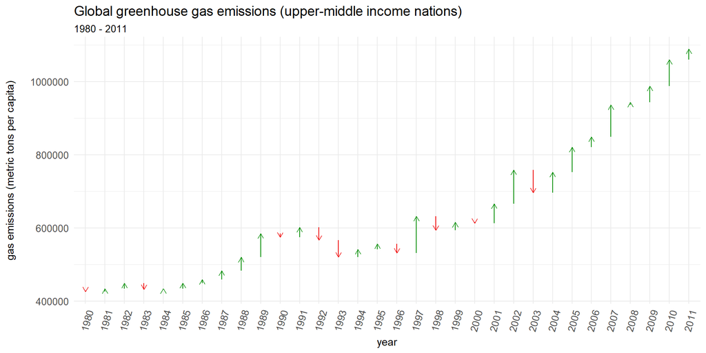

This visualization is a slightly different take on a time-series. Using coloured arrows helps the viewer better appreciate the magnitude of increase or decrease in greenhouse gas emissions year-to-year. As we can visually group each individual arrow into a larger picture, this plot still captures the overall trend in greenhouse gas emissions but also makes yearly comparisons much easier. Some decisions made which make this plot easier to read are the incorporation of major and minor y-axis grid lines and vertically adjusted labels for each year on the x-axis. I choose to only plot upper-middle class countries because these countries seemed to be the largest contributors to CO2 emissions (seen in the area plot before). The overall trend shows an increase in global greenhouse gas emissions overtime. In fact, there hasn’t been a year-to-year decline in greenhouse gas emissions since 2003. Even this decrease may be an artifact resulting from the significant increase in emissions the year before (from 2001-2002). In more recent years, the largest year-to-year increases in greenhouse gas emissions have been in 2007 and 2010.

# Minor and major progresses made in electricity access across sub-Saharan Africa, except Zimbabwe

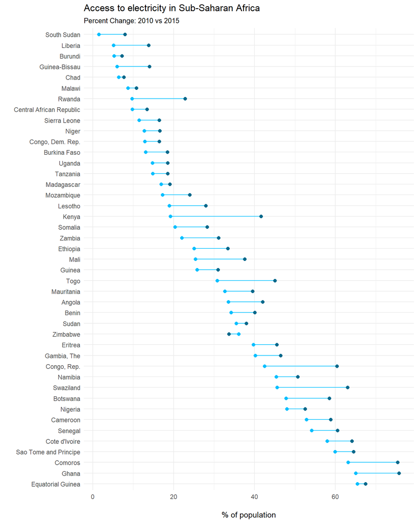

The goal of this visualization is to give the reader all the information he or she needs with only the graphical elements and no legend required. It should be intuitive what the colours and line segments mean so a legend is not required. Each point on the plot represents a year where light blue points represent 2010 and dark blue points represent 2015. The difference in colour is supposed to allow that change to be obvious and the viewer should be able to group similar coloured points into their respective years. This is aided further with the lines which connect them, making this idea quite obvious to understand. Again, the line lengths (similar to the arrow lengths in the last plot) denote the magnitude of chance between 2010 and 2015. I believe I adjusted the width of this plot perfectly to capture those magnitudes honestly within this context. Another important decision which greatly improves the readability of this plot was to order each country in terms of starting values in 2010. This ordering makes it easy to see which countries are above or below another and relative changes between countries.

The actual values being visualized have to do with an important developmental indicator: percentage of population with access to electricity in Sub-Saharan Africa. You can see that some countries, like Kenya and Swaziland, have made very large progress in improving access to electricity from 2010 to 2015. On the other hand, countries like Char and Madagascar have made very little over five years. Zimbabwe was actually worse off in 2015 than it was in 2010 in this regard. Ghana had the highest percentage of population with access to electricity in 2015, while Burundi had the lowest.